# IA-SVA based feature selection improves the performance of clustering algorithms [2]

Donghyung Lee

2018-05-03

Here, we used single cell RNA sequencing (scRNA-Seq) data with strong confounding variables, which is also obtained from human pancreatic islet samples (Xin et. al., 2016). This dataset is included in an R data package (“iasvaExamples”) containing data examples for IA-SVA (https://github.com/dleelab/iasvaExamples). To install the ‘iasvaExamples’ package, follow the instructions provided in the GitHub page.

## Load packages

```r
rm(list=ls())
library(sva)
library(Seurat)
```

```r
library(iasva)
library(iasvaExamples)
library(dbscan)
library(irlba)
library(Rtsne)
library(pheatmap)
library(corrplot)
library(DescTools) #pcc i.e., Pearson's contingency coefficient
library(RColorBrewer)
library(cluster)
library(SummarizedExperiment)
color.vec <- brewer.pal(8, "Set1")
tol21rainbow= c("#771155", "#AA4488", "#CC99BB", "#114477", "#4477AA",
                "#77AADD", "#117777", "#44AAAA", "#77CCCC", "#117744",
                "#44AA77", "#88CCAA", "#777711", "#AAAA44", "#DDDD77",
                "#774411", "#AA7744", "#DDAA77", "#771122", "#AA4455",
                "#DD7788")

# Normalization.
normalize <- function(counts)
{
    normfactor <- colSums(counts)
    return(t(t(counts)/normfactor)*median(normfactor))
}
```

## Load the islet scRNA-Seq data

```r
data("Xin_Islet_scRNAseq_Read_Counts")
data("Xin_Islet_scRNAseq_Annotations")
ls()
```

```
## [1] "color.vec"                      "normalize"
## [3] "tol21rainbow"                   "Xin_Islet_scRNAseq_Annotations"
## [5] "Xin_Islet_scRNAseq_Read_Counts"
```

```r
counts <- Xin_Islet_scRNAseq_Read_Counts
anns <- Xin_Islet_scRNAseq_Annotations
dim(anns)
```

```
## [1] 1600    9
```

```r
dim(counts)
```

```
## [1] 26542  1600
```

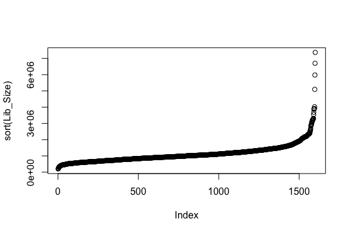

```r
Lib_Size <- colSums(counts)
plot(sort(Lib_Size))
```

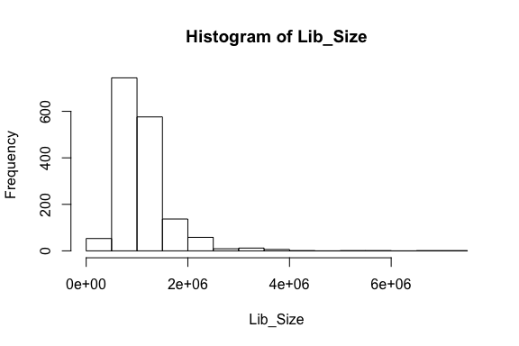

```r
hist(Lib_Size)
```

```r
summary(Lib_Size)
```

```
##    Min. 1st Qu.  Median    Mean 3rd Qu.    Max.
##  199678  773969 1002044 1104395 1288619 7369192
```

The annotations describing the islet samples and experimental settings are stored in “anns” and the read counts information is stored in “counts”.

## Filter out low-expressed genes

```r
dim(counts)
```

[1] 26542 1600

```r
dim(anns)
```

[1] 1600 9

```r
anns <- droplevels(anns)
prop.zeros <- sum(counts==0)/length(counts)
prop.zeros
```

[1] 0.7040829

```r
filter = apply(counts, 1, function(x) length(x[x>5])>=3)
counts = counts[filter,]
dim(counts)
```

[1] 19169 1600

```r
prop.zeros <- sum(counts==0)/length(counts)
prop.zeros
```

[1] 0.5913386

```r
summary(anns)
```

```
      X             Age        Cell_Type          Condition
```

SRR3541303: 1 Min. :23.00 alpha:946 non-diabetic:651  
SRR3541304: 1 1st Qu.:37.00 beta :503 T2D :949  
SRR3541305: 1 Median :42.00 delta: 58  
SRR3541306: 1 Mean :43.89 PP : 93  
SRR3541307: 1 3rd Qu.:55.00  
SRR3541308: 1 Max. :68.00  
(Other) :1594  
Donor_ID Ethnicity Gender Num_Expressed_Genes T2D 4 :306 AA:369 female:658 Min. :1745  
T2D 6 :224 AI: 45 male :942 1st Qu.:4412  
T2D 5 :176 C :593 Median :5158  
Non T2D 12:144 H :593 Mean :5185  
T2D 1 : 91 3rd Qu.:5902  
T2D 2 : 83 Max. :9731  
(Other) :576  
Mitochondrial_Fraction Min. : 0.2812  
1st Qu.: 4.1449  
Median : 6.3422  
Mean : 7.4164  
3rd Qu.:10.1241  
Max. :22.8479

```r
Patient_ID <- anns$Donor_ID
Gender <- anns$Gender
Age <- anns$Age
Cell_Type <- anns$Cell_Type
Phenotype <- anns$Condition
Ethnicity <- anns$Ethnicity
Mito_Frac <- anns$Mitochondrial_Fraction
table(Cell_Type, Patient_ID)
```

```
     Patient_ID
```

```r
ContCoef(table(Cell_Type, Patient_ID))
```

[1] 0.4832611

```r
table(Cell_Type, Gender)
```

```
     Gender
```

Cell_Type female male alpha 358 588 beta 244 259 delta 24 34 PP 32 61

```r
ContCoef(table(Cell_Type, Gender))
```

[1] 0.1033314

```r
table(Cell_Type, Age)
```

```
     Age
```

```r
ContCoef(table(Cell_Type, Age))
```

[1] 0.4782088

```r
table(Cell_Type, Phenotype)
```

```
     Phenotype
```

Cell_Type non-diabetic T2D alpha 377 569 beta 207 296 delta 28 30 PP 39 54

```r
ContCoef(table(Cell_Type, Phenotype))
```

[1] 0.03317408

```r
table(Cell_Type, Ethnicity)
```

```
     Ethnicity
```

Cell_Type AA AI C H alpha 213 14 384 335 beta 99 17 150 237 delta 16 3 22 17 PP 41 11 37 4

```r
ContCoef(table(Cell_Type, Ethnicity))
```

[1] 0.2517959

```r
ContCoef(table(Patient_ID, Gender))
```

[1] 0.7071068

```r
ContCoef(table(Patient_ID, Age))
```

[1] 0.9682458

```r
ContCoef(table(Patient_ID, Phenotype))
```

[1] 0.7071068

```r
ContCoef(table(Patient_ID, Ethnicity))
```

[1] 0.8660254

```r
ContCoef(table(Gender, Age))
```

[1] 0.6803731

```r
ContCoef(table(Gender, Phenotype))
```

[1] 0.1724809

```r
ContCoef(table(Gender, Ethnicity))
```

[1] 0.4526994

```r
ContCoef(table(Age, Phenotype))
```

[1] 0.7071068

```r
ContCoef(table(Age, Ethnicity))
```

[1] 0.8569589

```r
ContCoef(table(Phenotype, Ethnicity))
```

[1] 0.4785346

```r
raw.counts <- counts
summary(colSums(counts))
```

Min. 1st Qu. Median Mean 3rd Qu. Max. 199628 773880 1001875 1104286 1288589 7369004

```r
counts <- normalize(counts)
summary(colSums(counts))
```

Min. 1st Qu. Median Mean 3rd Qu. Max. 1001875 1001875 1001875 1001875 1001875 1001875

Note that the orignial cell assignments are highly correlated with known factors.

## Calculate the number of detected genes

It is well known that the number of detected genes in each cell explains a very large portion of variability in scRNA-Seq data ([Hicks et. al. 2015 BioRxiv](http://biorxiv.org/content/early/2015/08/25/025528), [McDavid et. al. 2016 Nature Biotechnology](http://www.nature.com/nbt/journal/v34/n6/full/nbt.3498.html)). Frequently, the first principal component of log-transformed scRNA-Seq read counts is highly correlated with the number of detected genes (e.g., r > 0.9). Here, we calculate the number of detected genes for islet cells, which will be used as an known factor in the IA-SVA analyses.

```r
Num_Detected_Genes <- colSums(counts>0)
summary(Num_Detected_Genes)
```

```
##    Min. 1st Qu.  Median    Mean 3rd Qu.    Max.
##    3261    6890    7832    7834    8766   12067
```

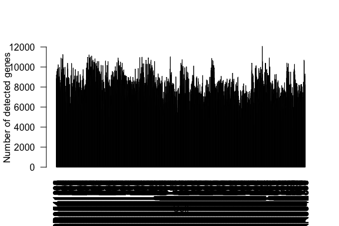

```r
barplot(Num_Detected_Genes, xlab="Cell", las=2, ylab = "Number of detected genes")
```

```r
lcounts <- log(counts + 1)
# PCA
pca.res = irlba(lcounts - rowMeans(lcounts), 5)$v
cor(Num_Detected_Genes, pca.res[,1])
```

```
## [1] -0.8906152
```

```r
dim(lcounts)
```

```
## [1] 19169  1600
```

## Run tSNE to cluster islet cells.

For comparison purposes,we applied tSNE on read counts of all genes. We used the Rtsne R package with default settings. Genes are color coded wrt their expression of marker genes.

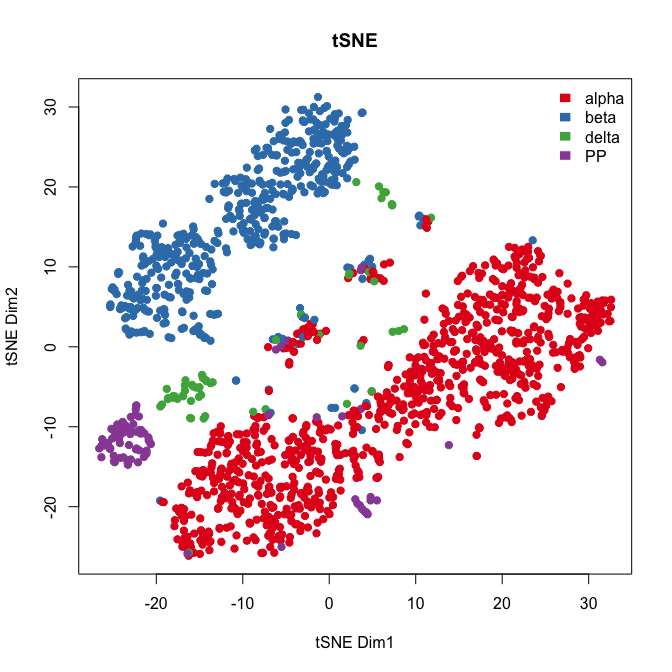

```r
set.seed(34544532)
tsne.res.all <- Rtsne(t(lcounts), dims = 2)
plot(tsne.res.all$Y, main="tSNE", xlab="tSNE Dim1",
     ylab="tSNE Dim2",pch=21, col=color.vec[Cell_Type],
     bg=color.vec[Cell_Type], oma=c(4,4,6,12))
legend("topright", levels(Cell_Type), border="white", fill=color.vec, bty="n")
```

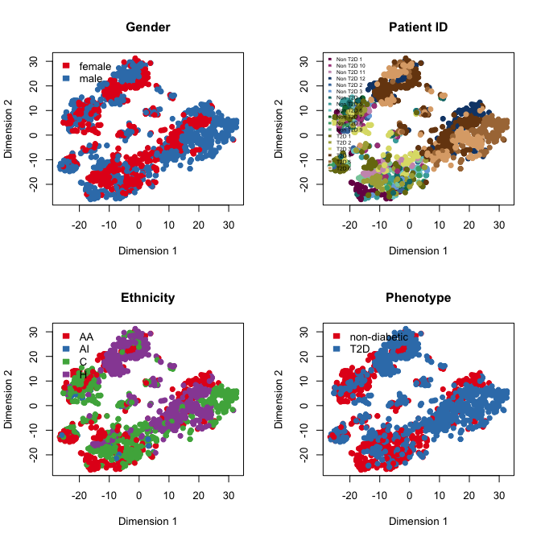

```r
par(mfrow=c(2,2))
plot(tsne.res.all$Y, main="Gender", xlab="Dimension 1",
     ylab="Dimension 2", pch=21, col=color.vec[Gender],
     bg=color.vec[Gender], oma=c(4,4,6,12))
legend("topleft", levels(Gender), border="white",
       fill=color.vec, bty="n")
plot(tsne.res.all$Y, main="Patient ID", xlab="Dimension 1",
     ylab="Dimension 2", pch=21, col=tol21rainbow[Patient_ID],
     bg=tol21rainbow[Patient_ID], oma=c(4,4,6,12))
legend("topleft", levels(Patient_ID), border="white",
       fill=tol21rainbow, bty="n", cex=0.5)
plot(tsne.res.all$Y, main="Ethnicity", xlab="Dimension 1",
     ylab="Dimension 2", pch=21, col=color.vec[Ethnicity],
     bg=color.vec[Ethnicity], oma=c(4,4,6,12))
legend("topleft", levels(Ethnicity), border="white",
       fill=color.vec, bty="n")
plot(tsne.res.all$Y, main="Phenotype", xlab="Dimension 1",
     ylab="Dimension 2", pch=21, col=color.vec[Phenotype],
     bg=color.vec[Phenotype], oma=c(4,4,6,12))
legend("topleft", levels(Phenotype), border="white", fill=color.vec, bty="n")
```

```r
par(mfrow=c(1,1))
```

Known factors deteriorate the performance of t-SNE.

## Run CellView to cluster islet cells

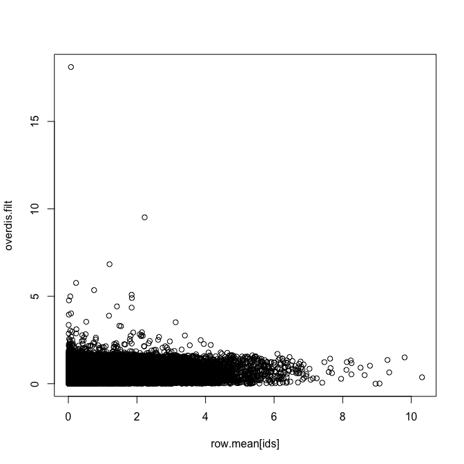

```r
# specify gene number to select for
gene_num <- 1000

# calcuclate dispersion
row.var <- apply(lcounts,1,sd)**2
row.mean <- apply(lcounts,1,mean)
dispersion <- row.var/row.mean

# generate sequence of bins
bins <- seq(from = min(row.mean), to = max(row.mean), length.out = 20)

# sort mean expression data into the bins
bin.exp <- row.mean
# sort the values
bin.sort <- sort(bin.exp, decreasing = FALSE)
# vector of bin assignment
cuts <- cut(x = bin.exp, breaks = bins, labels = FALSE)
# find which are NA and change to zero
na.ids <- which(is.na(cuts) == TRUE)
cuts[na.ids] <- 0

# create an empty vector for overdispersion
overdispersion <- NULL

# for each gene and bin index, calculate median, mad, and then normalized dispersion
# first loop through length of bins found
for (k in 1:length(names(table(cuts)))) {
  # find index of bins
  bin.id <- which(cuts == names(table(cuts))[k])
  # median of all genes in the bin
  median.bin <- median(dispersion[bin.id], na.rm = TRUE)
  # calculate mad (median absolute deviation)
  mad.bin <- mad(dispersion[bin.id])
  # calculate norm dispersion for each gene
  for (m in 1:length(bin.id)) {
    norm.dispersion <- abs(dispersion[bin.id[m]] - median.bin)/mad.bin
    overdispersion <- c(overdispersion, norm.dispersion)
  }
}

# remove nans
overdis.na <- which(is.na(overdispersion) == TRUE)
if (length(overdis.na) > 0) {
  overdis.filt <- overdispersion[-overdis.na]
} else {
  overdis.filt <- overdispersion
}


# plot mean expression vs overdisperssion
ids <- which(names(overdis.filt) %in% names(row.mean))
plot(row.mean[ids], overdis.filt)
```

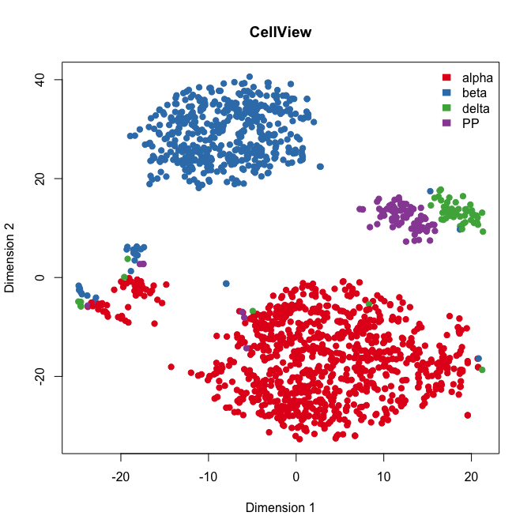

```r
# Do t-sne using top over-dispersed genes (apply mean expression filter too)
rank.ov <- order(overdis.filt, decreasing = TRUE)
ov.genes <- names(overdis.filt[rank.ov[1:gene_num]])
log.sel <- lcounts[ov.genes,]

all1 <- t(log.sel)
# Remove groups that are all zeros
df <- all1[,apply(all1, 2, var, na.rm=TRUE) != 0]

set.seed(45344)
rtsne_out <- Rtsne(as.matrix(df), dims = 3)

# Set rownames of matrix to tsne matrix
rownames(rtsne_out$Y) <- rownames(df)

plot(rtsne_out$Y[,c(1,2)], main="CellView", xlab="Dimension 1",
     ylab="Dimension 2",pch=21, col=color.vec[Cell_Type],
     bg=color.vec[Cell_Type], oma=c(4,4,6,12))
legend("topright", levels(Cell_Type), border="white", fill=color.vec, bty="n")
```

## Run Seurat to cluster islet cells

```r
set.seed(12344)
seurat.obj <- CreateSeuratObject(raw.data=counts,
                                 min.cells=3, min.genes=200, project="Seurat_Comp")

names(Patient_ID) <- rownames(seurat.obj@meta.data)
seurat.obj <- AddMetaData(object = seurat.obj,
                          metadata = Patient_ID, col.name = "patient.id")

# Normalizing the data
seurat.obj <- NormalizeData(object = seurat.obj, normalization.method = "LogNormalize",
    scale.factor = 10000)

# Detection of variable genes across the single cells
seurat.obj <- FindVariableGenes(object = seurat.obj, mean.function = ExpMean, dispersion.function = LogVMR,
    x.low.cutoff = 0.0125, x.high.cutoff = 3, y.cutoff = 0.5)
```

[figure not shown]

```r
length(x = seurat.obj@var.genes) #6639
```

```
## [1] 6639
```

```r
# Scaling the data and removing unwanted sources of variation
seurat.obj <- ScaleData(object = seurat.obj, vars.to.regress = c("nGene", "patient.id"))
```

```
## [1] "Regressing out nGene"      "Regressing out patient.id"
##
## Time Elapsed:  1.22467736800512 mins
## [1] "Scaling data matrix"
##
```

```r
# Perform linear dimensional reduction
seurat.obj <- RunPCA(object = seurat.obj, pc.genes = seurat.obj@var.genes, do.print = TRUE, pcs.print = 1:5,
    genes.print = 5)
```

```
## [1] "PC1"
## [1] "TM4SF4" "GC"     "GLS"    "FAP"    "PAPPA2"
## [1] ""
## [1] "HADH"    "TIMP2"   "SYNE2"   "ADCYAP1" "PCSK1"
## [1] ""
## [1] ""
## [1] "PC2"
## [1] "ADCYAP1" "HADH"    "ERO1LB"  "PFKFB2"  "NPTX2"
## [1] ""
## [1] "IFITM3" "SPARC"  "LGALS1" "COL1A2" "COL1A1"
## [1] ""
## [1] ""
## [1] "PC3"
## [1] "COL1A2"  "COL3A1"  "BGN"     "SPARC"   "COL15A1"
## [1] ""
## [1] "CFTR"     "MMP7"     "LCN2"     "KRT19"    "PDZK1IP1"
## [1] ""
## [1] ""
## [1] "PC4"
## [1] "SLITRK6" "CALCRL"  "THSD7A"  "CALB1"   "ETV1"
## [1] ""
## [1] "PFKFB2" "ANXA2"  "ROBO2"  "RIN2"   "ENO1"
## [1] ""
## [1] ""
## [1] "PC5"
## [1] "ETV1"    "CALB1"   "SLITRK6" "SPOCK1"  "THSD7A"
## [1] ""
## [1] "PODXL" "CD93"  "FLT1"  "PLVAP" "ESAM"
## [1] ""
## [1] ""
```

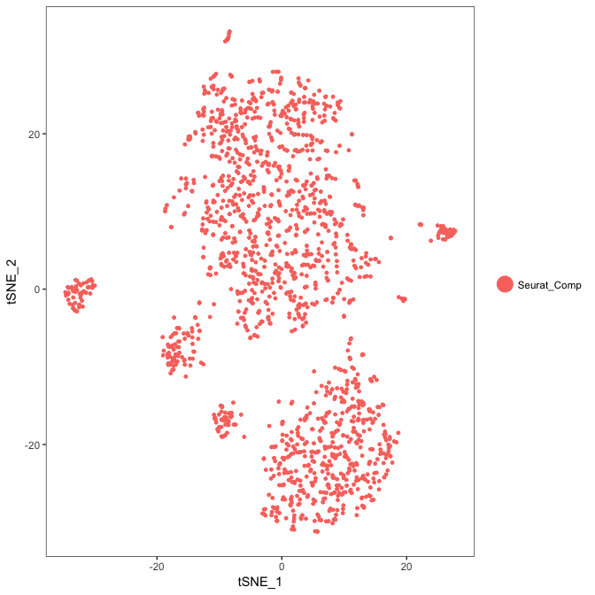

```r
# Determine statistically significant principal components
if(FALSE){
seurat.obj <- JackStraw(object = seurat.obj, num.replicate = 100, do.print = FALSE)
JackStrawPlot(object = seurat.obj, PCs = 1:20)
PCElbowPlot(object = seurat.obj)
# Cluster the cells
seurat.obj <- FindClusters(object = seurat.obj, reduction.type = "pca", dims.use = 1:10,
    resolution = 0.6, print.output = 0, save.SNN = TRUE)
PrintFindClustersParams(object = seurat.obj)
}

set.seed(12344454)
seurat.obj <- RunTSNE(object = seurat.obj, dims.use = 1:10, do.fast = TRUE)
TSNEPlot(object = seurat.obj)
```

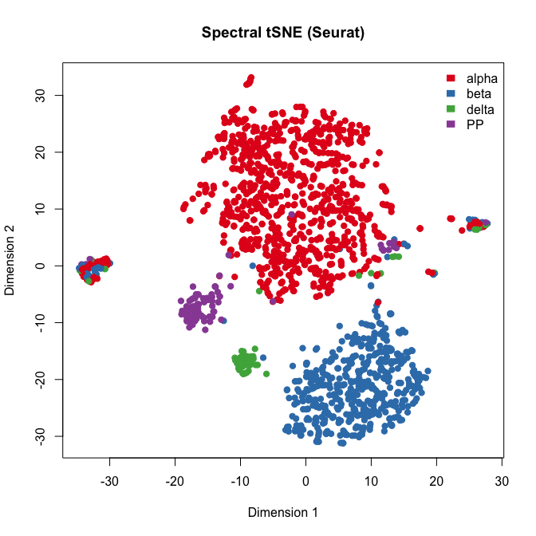

```r
# with true cell types
plot(seurat.obj@dr$tsne@cell.embeddings[,c(1,2)],
     main="Spectral tSNE (Seurat)", xlab="Dimension 1",
     ylab="Dimension 2",pch=21, col=color.vec[Cell_Type],
     bg=color.vec[Cell_Type], oma=c(4,4,6,12))
legend("topright", levels(Cell_Type), border="white", fill=color.vec, bty="n")
```

## Run PCA to cluster islet cells. Here, we applied PCA on read counts of all genes. Genes are color coded with their expression of marker genes.

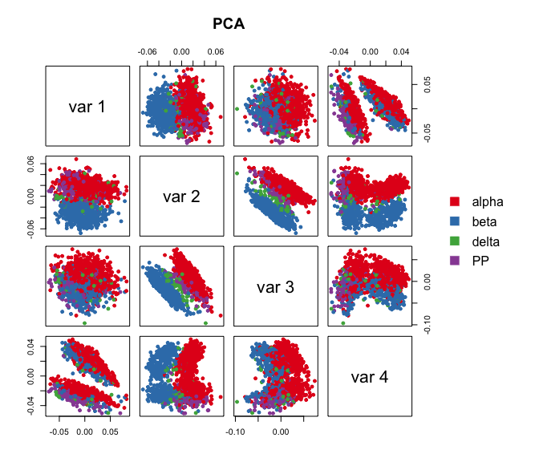

```r
pairs(pca.res[,1:4], main="PCA", pch=21, col=color.vec[Cell_Type],
      bg=color.vec[Cell_Type], cex=0.8, oma=c(4,4,6,12))
legend("right", levels(Cell_Type), border="white", fill=color.vec, bty="n")
```

## Run surrogate variable analysis (SVA).

```r
set.seed(34544455)
mod1 <- model.matrix(~Patient_ID+Num_Detected_Genes)
mod0 <- cbind(mod1[,1])
sva.res = svaseq(counts,mod1,mod0, n.sv=4)$sv
```

```
## Number of significant surrogate variables is:  4
## Iteration (out of 5 ):1  2  3  4  5
```

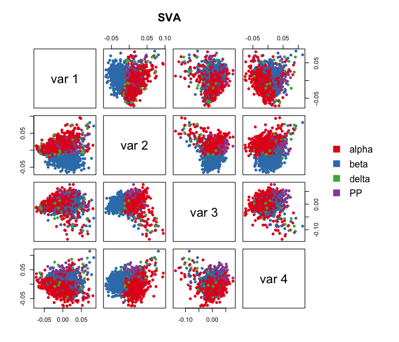

```r
pairs(sva.res[,1:4], main="SVA", pch=21, col=color.vec[Cell_Type],
      bg=color.vec[Cell_Type], cex=0.8, oma=c(4,4,6,12))
legend("right", levels(Cell_Type), border="white", fill=color.vec, bty="n")
```

## Run IA-SVA

```r
set.seed(345466666)
mod <- model.matrix(~Patient_ID+Num_Detected_Genes)
summ_exp <- SummarizedExperiment(assays = counts)
iasva.res<- iasva(summ_exp, mod[,-1],verbose=FALSE, permute=FALSE, num.sv=4)
```

```
## IA-SVA running...
## SV1 Detected!
## SV2 Detected!
## SV3 Detected!
## SV4 Detected!
## # of significant surrogate variables: 4
```

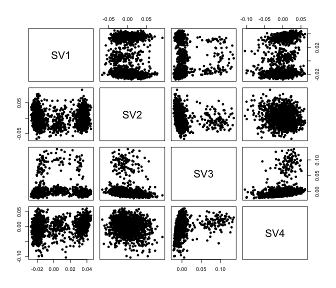

```r
iasva.sv <- iasva.res$sv

## no color
pairs(iasva.sv[,1:4], pch=21, col="black", bg="black", cex=0.8)
```

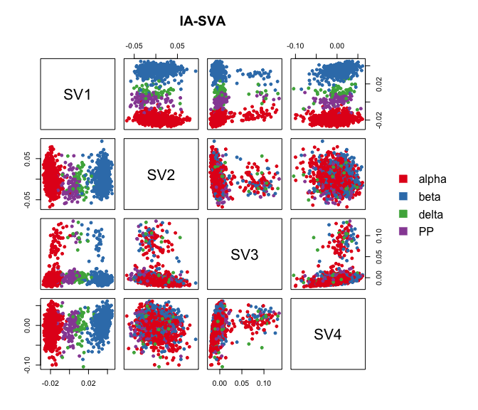

```r
## with color-coding
pairs(iasva.sv[,1:4], main="IA-SVA", pch=21, col=color.vec[Cell_Type],
      bg=color.vec[Cell_Type], cex=0.8, oma=c(4,4,6,12))
legend("right", levels(Cell_Type), border="white", fill=color.vec, bty="n")
```

## Correlation between SVs

```r
cor(iasva.sv)
```

```
##            SV1         SV2         SV3        SV4
## SV1 1.00000000  0.03808617  0.06200799  0.2507764
## SV2 0.03808617  1.00000000 -0.15724552 -0.1830763
## SV3 0.06200799 -0.15724552  1.00000000  0.2474547
## SV4 0.25077642 -0.18307630  0.24745468  1.0000000
```

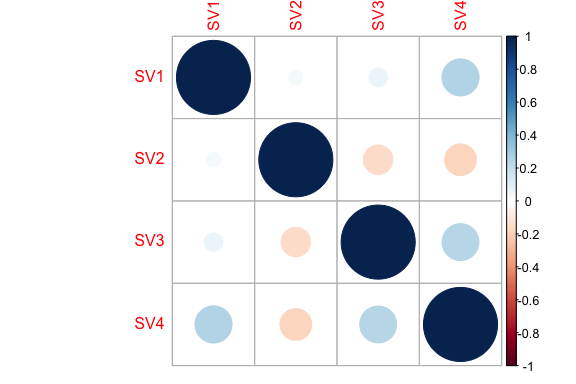

```r
corrplot(cor(iasva.sv))
```

## clustering analyses

Here, try different R2 cutoffs

```r
no.clusters <- 4
C.scores <- matrix(0,0,0)
Number.of.genes <- matrix(0,0,0)
for (i in seq(0.1,0.9,0.05)){
  marker.counts <- find_markers(summ_exp, as.matrix(iasva.sv[,2]), rsq.cutoff = i)
  no.genes <- dim(marker.counts)[1]
  if(no.genes == 0){
    break
  }
  else{
    my.dist <- dist(t(log(marker.counts+1)))
    my.clustering <- hclust(my.dist, method = "ward.D2")
    my.silhoutte <-silhouette(cutree(my.clustering,no.clusters),my.dist)
    C1 <- mean(my.silhoutte[my.silhoutte[,1]==1,3])
    C2 <- mean(my.silhoutte[my.silhoutte[,1]==2,3])
    average.C <- (C1+C2)/2
    C.scores <- c(C.scores, average.C)
    Number.of.genes <- c(Number.of.genes,no.genes)
  }
}
```

```
## # of markers (): 2204
## total # of unique markers:  2204# of markers (): 1326
## total # of unique markers:  1326# of markers (): 839
## total # of unique markers:  839# of markers (): 528
## total # of unique markers:  528# of markers (): 329
## total # of unique markers:  329# of markers (): 190
## total # of unique markers:  190# of markers (): 111
## total # of unique markers:  111# of markers (): 57
## total # of unique markers:  57# of markers (): 30
## total # of unique markers:  30# of markers (): 15
## total # of unique markers:  15# of markers (): 2
## total # of unique markers:  2# of markers (): 0
## total # of unique markers:  0
```

```r
output.matrix <- rbind(C.scores, Number.of.genes)


pdf("Clustering_analyses_figure4_Xin.pdf")
par(mar=c(5,5,5,5))
end.point <- (length(C.scores)-1)*0.05+0.1
plot(Number.of.genes,  xlab = "R^2", ylab = "Number genes selected", xaxt="n", main = "Number of selected genes vs. Cluster quality", pch = 18, col ="blue",type="b", lty=2, cex=2)
Axis(1,at=seq(1,length(Number.of.genes)), side = 1, labels=seq(0.1,end.point,0.05),las = 2)
par(new=T)
plot(C.scores, xlab='', ylab='', axes=F, pch = 18 , col ="red",type="b", lty=2, cex=2)
Axis(side=4)
mtext(side = 4, line = 2, 'Average Silhoutte Score', col = "red")
par(new=F)
dev.off()
```

## Find marker genes for SV1.

```r
# try different R2 thresholds
pdf("Clustering_analyses_figure4_Xin_sv1.pdf")
r2.results <- study_R2(summ_exp, iasva.sv,selected.svs=1, no.clusters=2)
```

```
## # of markers (): 369
## total # of unique markers:  369# of markers (): 198
## total # of unique markers:  198# of markers (): 123
## total # of unique markers:  123# of markers (): 87
## total # of unique markers:  87# of markers (): 57
## total # of unique markers:  57# of markers (): 44
## total # of unique markers:  44# of markers (): 37
## total # of unique markers:  37# of markers (): 26
## total # of unique markers:  26# of markers (): 20
## total # of unique markers:  20# of markers (): 14
## total # of unique markers:  14# of markers (): 12
## total # of unique markers:  12# of markers (): 8
## total # of unique markers:  8# of markers (): 7
## total # of unique markers:  7# of markers (): 5
## total # of unique markers:  5# of markers (): 4
## total # of unique markers:  4# of markers (): 1
## total # of unique markers:  1# of markers (): 0
## total # of unique markers:  0
```

```r
dev.off()
```

```r
marker.counts <- find_markers(summ_exp, as.matrix(iasva.sv[,c(1)]),  rsq.cutoff = 0.3)
```

```
## # of markers (): 57
## total # of unique markers:  57
```

```r
nrow(marker.counts)
```

```
## [1] 57
```

```r
marker.counts.long <- find_markers(summ_exp, as.matrix(iasva.sv[,c(1)]),  rsq.cutoff = 0.2)
```

```
## # of markers (): 123
## total # of unique markers:  123
```

```r
nrow(marker.counts.long)
```

```
## [1] 123
```

```r
anno.col <- data.frame(Cell_Type=Cell_Type)
rownames(anno.col) <- colnames(marker.counts)
head(anno.col)
```

```
##            Cell_Type
## SRR3541303      beta
## SRR3541304      beta
## SRR3541305      beta
## SRR3541306      beta
## SRR3541307      beta
## SRR3541308      beta
```

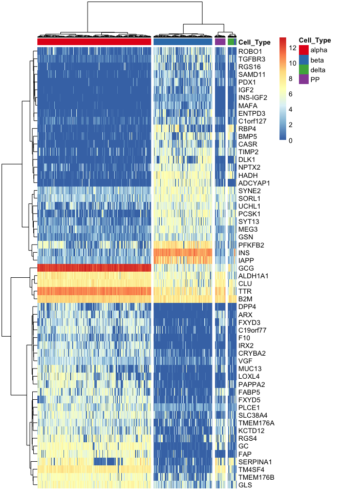

```r
cell.type.col <- color.vec[1:4]
names(cell.type.col) <- c("alpha","beta","delta","PP")
anno.colors <- list(Cell_Type=cell.type.col)

pheatmap(log(marker.counts+1), show_colnames =FALSE, show_rownames = TRUE,
         clustering_method = "ward.D2",cutree_cols = 4,
         annotation_col = anno.col, annotation_colors=anno.colors)
```

## Find marker genes for SV3.

```r
marker.counts.SV3 <- find_markers(summ_exp, as.matrix(iasva.sv[,c(3)]),  rsq.cutoff = 0.3)
```

```
## # of markers (): 54
## total # of unique markers:  54
```

```r
nrow(marker.counts.SV3)
```

```
## [1] 54
```

```r
marker.counts.SV3.long <- find_markers(summ_exp, as.matrix(iasva.sv[,c(3)]),  rsq.cutoff = 0.2)
```

```
## # of markers (): 138
## total # of unique markers:  138
```

```r
nrow(marker.counts.SV3.long)
```

```
## [1] 138
```

```r
anno.col <- data.frame(Cell_Type=Cell_Type, SV3=iasva.sv[,3])
rownames(anno.col) <- colnames(marker.counts.SV3)
head(anno.col)
```

```
##            Cell_Type           SV3
## SRR3541303      beta  0.0070956379
## SRR3541304      beta -0.0006460813
## SRR3541305      beta -0.0116911796
## SRR3541306      beta -0.0044453589
## SRR3541307      beta  0.0008762206
## SRR3541308      beta -0.0080419417
```

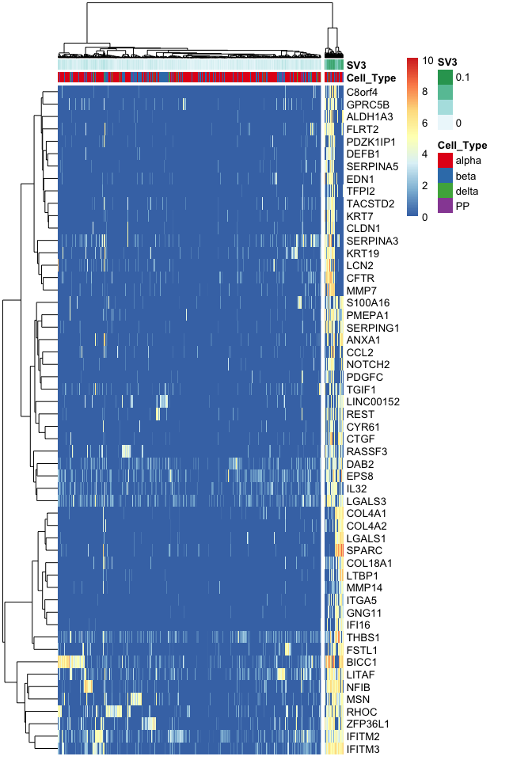

```r
cell.type.col <- color.vec[1:4]
names(cell.type.col) <- c("alpha","beta","delta","PP")
anno.colors <- list(Cell_Type=cell.type.col)

pheatmap(log(marker.counts.SV3+1), show_colnames =FALSE, show_rownames = TRUE, clustering_method = "ward.D2",cutree_cols = 2,annotation_col = anno.col, annotation_colors=anno.colors)
```

## Run tSNE post IA-SVA, i.e., run tSNE on marker genes obtained from IA-SVA.

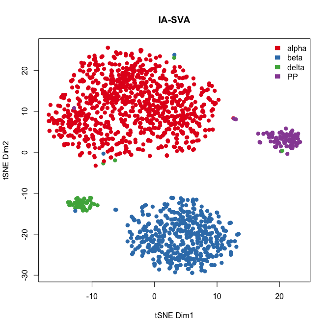

```r
set.seed(75458456)
tsne.res.iasva <- Rtsne(unique(t(log(marker.counts+1))), dims = 2)

plot(tsne.res.iasva$Y[,1:2], main="IA-SVA", xlab="tSNE Dim1",
     ylab="tSNE Dim2", pch=21, col=color.vec[Cell_Type],
     bg=color.vec[Cell_Type], oma=c(4,4,6,12))
legend("topright", levels(Cell_Type), border="white", fill=color.vec, bty="n")
```

tSNE performed on marker genes selected via IA-SVA performs better than original tSNE analyses using all genes. This example again reiterates the importance of gene selection using IA-SVA for effective clustering of single-cell datasets.

```r
pdf(file="Xin_Islets_All_demensionality_reduction_Figure4DEFG.pdf", width=8, height=9)
par(mfrow=c(2,2))
plot(tsne.res.all$Y, main="tSNE", xlab="Dimension 1", ylab="Dimension 2",pch=21, col=color.vec[Cell_Type], bg=color.vec[Cell_Type])
legend("topleft", levels(Cell_Type), border="white", fill=color.vec, bty="n")
plot(tsne.res.iasva$Y, main="IA-SVA + tSNE", xlab="Dimension 1", ylab="Dimension 2", pch=21, col=color.vec[Cell_Type], bg=color.vec[Cell_Type])
plot(rtsne_out$Y[,c(1,2)], main="CellView", xlab="Dimension 1", ylab="Dimension 2",pch=21, col=color.vec[Cell_Type], bg=color.vec[Cell_Type])
plot(seurat.obj@dr$tsne@cell.embeddings[,c(1,2)], main="Spectral tSNE (Seurat)", xlab="Dim1", ylab="Dim2",pch=21, col=color.vec[Cell_Type], bg=color.vec[Cell_Type])
dev.off()
```

```r
pdf(file="Xin_Islets_AllCells_tSNEByKnownFactors_FigureS9.pdf", width=10, height=11)
par(mfrow=c(2,2))
plot(tsne.res.all$Y, main="Gender", xlab="Dimension 1", ylab="Dimension 2", pch=21, col=color.vec[Gender], bg=color.vec[Gender], oma=c(4,4,6,12))
legend("topleft", levels(Gender), border="white", fill=color.vec, bty="n")
plot(tsne.res.all$Y, main="Patient ID", xlab="Dimension 1", ylab="Dimension 2", pch=21, col=tol21rainbow[Patient_ID], bg=tol21rainbow[Patient_ID], oma=c(4,4,6,12))
legend("topleft", levels(Patient_ID), border="white", fill=tol21rainbow, bty="n", cex=0.5)
plot(tsne.res.all$Y, main="Ethnicity", xlab="Dimension 1", ylab="Dimension 2", pch=21, col=color.vec[Ethnicity], bg=color.vec[Ethnicity], oma=c(4,4,6,12))
legend("topleft", levels(Ethnicity), border="white", fill=color.vec, bty="n")
plot(tsne.res.all$Y, main="Phenotype", xlab="Dimension 1", ylab="Dimension 2", pch=21, col=color.vec[Phenotype], bg=color.vec[Phenotype], oma=c(4,4,6,12))
legend("topleft", levels(Phenotype), border="white", fill=color.vec, bty="n")
par(mfrow=c(1,1))
dev.off()
```

```r
pdf(file="Xin_Islets_AllCells_IASVA_nocolor.pdf", width=4, height=4)
pairs(iasva.sv[,1:4], pch=21, col="black", bg="black", cex=0.3)
dev.off()
```

```r
pdf(file="Xin_Islets_AllCells_IASVA.pdf", width=4, height=4)
pairs(iasva.sv[,1:4], pch=21, col=color.vec[Cell_Type], bg=color.vec[Cell_Type], cex=0.3)
dev.off()
```

```r
pdf(file="Xin_Islets_AllCells_PCA.pdf", width=4, height=4)
pairs(pca.res[,1:4], pch=21, col=color.vec[Cell_Type], bg=color.vec[Cell_Type], cex=0.3)#
dev.off()
```

```r
colnames(sva.res) <- paste0("SV",1:4)
pdf(file="Xin_Islets_AllCells_USVA.pdf", width=4, height=4)
pairs(sva.res[,1:4], pch=21, col=color.vec[Cell_Type], bg=color.vec[Cell_Type], cex=0.3) #4,4,6,12
dev.off()
```

```r
anno.col <- data.frame(Cell_Type=Cell_Type)
rownames(anno.col) <- colnames(marker.counts)
head(anno.col)
```

```
##            Cell_Type
## SRR3541303      beta
## SRR3541304      beta
## SRR3541305      beta
## SRR3541306      beta
## SRR3541307      beta
## SRR3541308      beta
```

```r
cell.type.col <- color.vec[1:4]
names(cell.type.col) <- c("alpha","beta","delta","PP")
anno.colors <- list(Cell_Type=cell.type.col)

pheatmap(log(marker.counts+1), show_colnames =FALSE, show_rownames = TRUE,
         clustering_method = "ward.D2",cutree_cols = 4,annotation_col = anno.col, annotation_colors=anno.colors,
         filename="FigureS11_Xin_Islets_AllCells_IASVA_Markers_pheatmap.pdf", width=10, height=10)
```

```r
write.table(as.data.frame(rownames(marker.counts)), file="Xin_Islets_AllCells_SV1_Genes_rsqcutoff0.3.txt", quote=F,
              row.names=F, col.names=F, sep=" ")

write.table(as.data.frame(rownames(marker.counts.long)), file="Xin_Islets_AllCells_SV1_Genes_rsqcutoff0.2.txt", quote=F,
              row.names=F, col.names=F, sep=" ")
```

```r
write.table(as.data.frame(rownames(marker.counts.SV3)), file="Xin_Islets_AllCells_SV3_Genes_rsqcutoff0.3.txt", quote=F,
              row.names=F, col.names=F, sep=" ")

write.table(as.data.frame(rownames(marker.counts.SV3.long)), file="Xin_Islets_AllCells_SV3_Genes_rsqcutoff0.2.txt", quote=F,
              row.names=F, col.names=F, sep=" ")
```